# PML_MY_PROJECT

Juan David Bejarano

22 de julio de 2015

# Final Project: Practical Machine Learning

Fist of all, I want to apologyze if there are some gramar error. English is not my mother language.

## Objetives

The goal of your project is to predict “How well” six participants of an experiment did the exercise

```r
library(caret)
```

```r
library(rpart)
library(rpart.plot)
library(reshape2)
library(RColorBrewer)
library(rattle)
library(randomForest)
library(gbm)
library(ggplot2) # Visualise data.
library(plyr)
library(dplyr)
library(pheatmap) # Heatmaps.
```

## Importing Data

The training data set:

```r
trainpath <- "https://d396qusza40orc.cloudfront.net/predmachlearn/pml-training.csv"
```

The testing data set:

```r
testpath <- "https://d396qusza40orc.cloudfront.net/predmachlearn/pml-testing.csv"
```

```r
trainFile <- "./data/pml-training.csv"
testFile  <- "./data/pml-testing.csv"
if (!file.exists("./data")) {
  dir.create("./data")
}
if (!file.exists(trainFile)) {
  download.file(trainpath, destfile=trainFile, method="libcurl")
}
if (!file.exists(testFile)) {
  download.file(testpath, destfile=testFile, method="libcurl")
}
training <- read.csv(trainFile, na.strings=c("NA","#DIV/0!",""))
testing <- read.csv(testFile, na.strings=c("NA","#DIV/0!",""))
```

## Cleaning Data

Removing variables with more than 60% missing values

```r
RMTrain <- training[, colSums(is.na(training)) <= 0.6*nrow(training)]
RMTest <- testing[, colSums(is.na(testing)) <= 0.6*nrow(testing)]
```

### Removing First 7 variables that looks unimportant

```r
RMTrain <- RMTrain[-c(1:7)]
RMTest <- RMTest[-c(1:7)]
```

### Removing Near to zero Variables

```r
zerovar <- nearZeroVar(RMTrain, saveMetrics = T)
RMTrain <- RMTrain[, !zerovar$nzv]
RMTest <- RMTest[, !zerovar$nzv]
```

## Data Slicing

Now we are going to load a Training and a Validation Set. We will use the validation data set to conduct cross validation in future steps.

60% for the training 40% for the testing

```r
set.seed(21541)
inTrain <- createDataPartition(RMTrain$classe, p=0.60, list=F)
mytraining <- RMTrain[inTrain,]
mytesting <- RMTrain[-inTrain,]
dim(mytraining);dim(mytesting)
```

```
## [1] 11776    53
```

```
## [1] 7846   53
```

## Looking for Correlations

Standardize each variable to mean 0 and standard deviation 1 using scale().

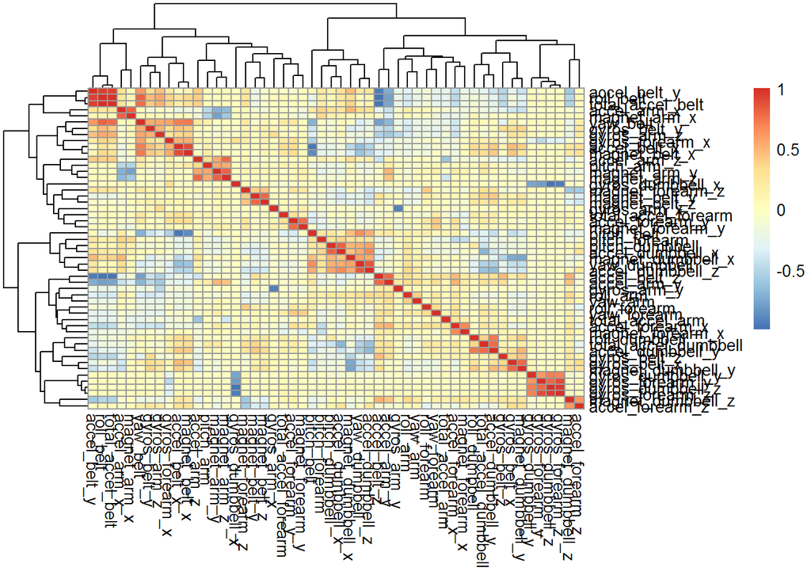

```r
Mytrain_scale<- scale(mytraining[,-53],center=TRUE,scale=TRUE);
descrCor <-  cor(Mytrain_scale)

#Transpose the matrix to show the variables as rows rather than columns, just for convenient viewing,
pheatmap(t(descrCor))
```

We descover that there are variable with high correlation, so we are going to work for solve this

```r
highCorr <- sum(abs(descrCor[upper.tri(descrCor)]) > .8)
summary(descrCor[upper.tri(descrCor)])
```

```
##       Min.    1st Qu.     Median       Mean    3rd Qu.       Max.
## -0.9920000 -0.1106000  0.0002492  0.0015650  0.0919500  0.9808000
```

## Data Modelling

### Clasification Trees

I tried different option witgh validation and Variables transformation (scaling). The better result was given by proproccesing with scaling and 10-fold cross validation

```r
set.seed(21541)
modTree<- train(mytraining$classe ~ ., data = mytraining, method="rpart",preProcess=c("center", "scale"),trControl=trainControl(method = "cv", number = 10))
predictionsTree <- predict(modTree, newdata =  mytesting)
print(confusionMatrix(predictionsTree, mytesting$classe))
```

```
## Confusion Matrix and Statistics
##
##           Reference
## Prediction    A    B    C    D    E
##          A 2033  631  639  573  220
##          B   29  511   44  221  187
##          C  165  376  685  492  377
##          D    0    0    0    0    0
##          E    5    0    0    0  658
##
## Overall Statistics
##
##                Accuracy : 0.4954
##                  95% CI : (0.4843, 0.5065)
##     No Information Rate : 0.2845
##     P-Value [Acc > NIR] : < 2.2e-16
##
##                   Kappa : 0.3404
##  Mcnemar's Test P-Value : NA
##
## Statistics by Class:
##
##                      Class: A Class: B Class: C Class: D Class: E
## Sensitivity            0.9108  0.33663  0.50073   0.0000  0.45631
## Specificity            0.6325  0.92399  0.78234   1.0000  0.99922
## Pos Pred Value         0.4963  0.51512  0.32697      NaN  0.99246
## Neg Pred Value         0.9469  0.85308  0.88124   0.8361  0.89085
## Prevalence             0.2845  0.19347  0.17436   0.1639  0.18379
## Detection Rate         0.2591  0.06513  0.08731   0.0000  0.08386
## Detection Prevalence   0.5220  0.12643  0.26702   0.0000  0.08450
## Balanced Accuracy      0.7717  0.63031  0.64154   0.5000  0.72776
```

No so Good Result.

### Boosting Model

Applying Boosting method with 10-fold cross validation

```r
set.seed(21541)
boostFit <- train(classe ~ ., method = "gbm", data = mytraining, verbose = F, trControl = trainControl(method = "cv", number = 10))
boostFit
```

```
## Stochastic Gradient Boosting
##
## 11776 samples
##    52 predictor
##     5 classes: 'A', 'B', 'C', 'D', 'E'
##
## No pre-processing
## Resampling: Cross-Validated (10 fold)
##
## Summary of sample sizes: 10598, 10598, 10599, 10599, 10598, 10598, ...
##
## Resampling results across tuning parameters:
##
##   interaction.depth  n.trees  Accuracy   Kappa      Accuracy SD
##   1                   50      0.7589163  0.6944574  0.006000205
##   1                  100      0.8226897  0.7756298  0.009024623
##   1                  150      0.8537703  0.8150026  0.007118848
##   2                   50      0.8548730  0.8161333  0.009740286
##   2                  100      0.9056533  0.8806057  0.008334262
##   2                  150      0.9318094  0.9137199  0.009477069
##   3                   50      0.8935093  0.8651792  0.010295951
##   3                  100      0.9403843  0.9245701  0.009122812
##   3                  150      0.9602575  0.9497205  0.005912631
##   Kappa SD
##   0.007540006
##   0.011538409
##   0.009136530
##   0.012318442
##   0.010578045
##   0.012010172
##   0.013061871
##   0.011558198
##   0.007479071
##
## Tuning parameter 'shrinkage' was held constant at a value of 0.1
##
## Tuning parameter 'n.minobsinnode' was held constant at a value of 10
## Accuracy was used to select the optimal model using  the largest value.
## The final values used for the model were n.trees = 150,
##  interaction.depth = 3, shrinkage = 0.1 and n.minobsinnode = 10.
```

The boosting algorith perform better than the decition trees.

### Ramdon Forest

Now we are going to apply Random Forest with 10-fold cross validation to predict classe with all other predictors.

```r
set.seed(21541)
rfFit <- train(classe ~ ., method = "rf", data = mytraining, importance = T, trControl = trainControl(method = "cv", number = 10))
rfFit
```

```
## Random Forest
##
## 11776 samples
##    52 predictor
##     5 classes: 'A', 'B', 'C', 'D', 'E'
##
## No pre-processing
## Resampling: Cross-Validated (10 fold)
##
## Summary of sample sizes: 10598, 10598, 10599, 10599, 10598, 10598, ...
##
## Resampling results across tuning parameters:
##
##   mtry  Accuracy   Kappa      Accuracy SD  Kappa SD
##    2    0.9904886  0.9879678  0.001996057  0.002524391
##   27    0.9909990  0.9886135  0.003000409  0.003795199
##   52    0.9849690  0.9809852  0.002438413  0.003084873
##
## Accuracy was used to select the optimal model using  the largest value.
## The final value used for the model was mtry = 27.
```

The result from Random Forest was better than the preceeding two methods in the training set.

```r
dev.off()
```

```r
plot(rfFit, ylim = c(0.9, 1))
```

[output not shown]

Now we are going to prove it in the Testing set

```r
rf.prediction <- predict(rfFit, mytesting)
cfMatrix <- confusionMatrix(rf.prediction, mytesting$classe)
cfMatrix$table
```

```
##           Reference
## Prediction    A    B    C    D    E
##          A 2228   19    0    0    0
##          B    4 1496    6    0    1
##          C    0    3 1360   17    4
##          D    0    0    2 1269    3
##          E    0    0    0    0 1434
```

## Out of sample error

The out of sample error shows to be really low.

```r
oose <- 1 - as.numeric(confusionMatrix(rf.prediction, mytesting$classe)$overall[1])
oose
```

```
## [1] 0.007519755
```

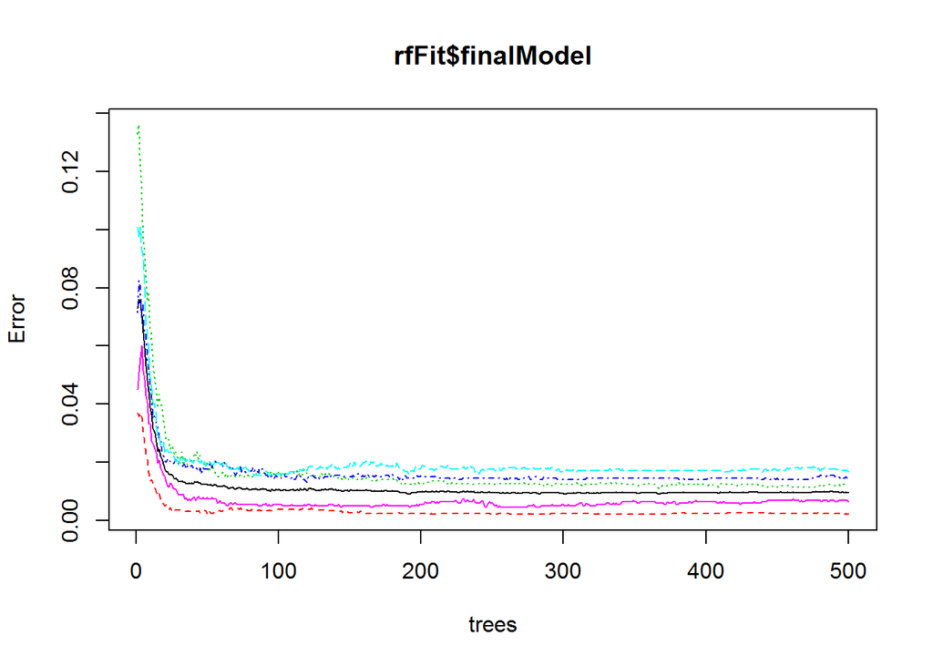

```r
plot(rfFit$finalModel)
```

```r
rfFit$finalModel
```

```
##
## Call:
##  randomForest(x = x, y = y, mtry = param$mtry, importance = ..1)
##                Type of random forest: classification
##                      Number of trees: 500
## No. of variables tried at each split: 27
##
##         OOB estimate of  error rate: 0.94%
## Confusion matrix:
##      A    B    C    D    E class.error
## A 3341    4    2    0    1 0.002090800
## B   17 2252    9    1    0 0.011847301
## C    0   18 2023   13    0 0.015092502
## D    0    1   27 1898    4 0.016580311
## E    0    2    5    7 2151 0.006466513
```

It is a very low oout of sample error rate: 0,94%.

The final random forests model contains 500 trees with 27 variables tried at each split.

## What is the importance of the predictors

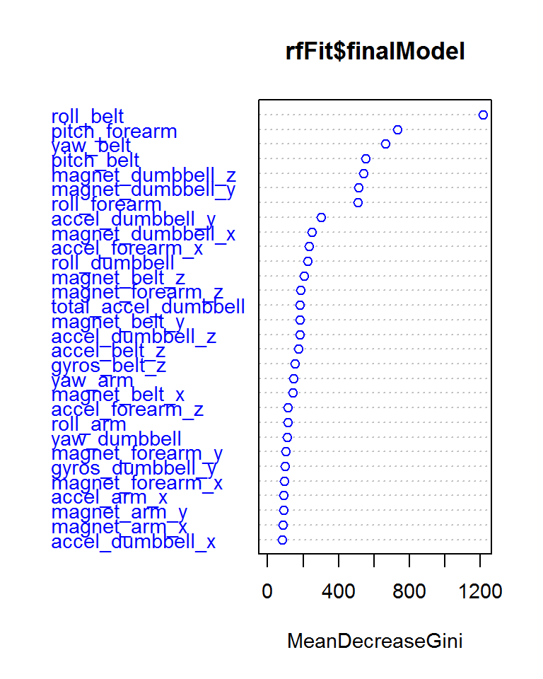

```r
varImpPlot(rfFit$finalModel,cex=0.9, col ="blue", type=2)
```

## Prediction

```r
Prediction <- predict(rfFit, RMTest)
Prediction
```

```
##  [1] B A B A A E D B A A B C B A E E A B B B
## Levels: A B C D E
```